# ----------------------------------------

# SL - HW5 - Q6

# ----------------------------------------

# Niloufar Abbasi - 401209996

# ----------------------------------------

##### لطفا سلول های کد را به ترتیب اجرا کنید

### libraries :

```python
import numpy             as np
import pandas            as pd
import matplotlib.pyplot as plt
import seaborn           as sns

from sklearn.preprocessing   import MinMaxScaler
from sklearn.ensemble        import RandomForestClassifier
from sklearn                 import metrics
from sklearn.model_selection import train_test_split
from sklearn.metrics         import classification_report
from sklearn.metrics         import confusion_matrix
from sklearn.metrics         import accuracy_score
from sklearn.model_selection import GridSearchCV
```

```python
train_df = pd.read_csv('E:\\sharif\\Statistical_Learning\\HW\\HW5\\Q6\\train.csv')
train_df.head(10)
```

|  | PassengerId | Survived | Pclass | Name | Sex | Age | SibSp | Parch | Ticket | Fare | Cabin | Embarked |
| --- | --- | --- | --- | --- | --- | --- | --- | --- | --- | --- | --- | --- |
| 0 | 1 | 0 | 3 | Braund, Mr. Owen Harris | male | 22.0 | 1 | 0 | A/5 21171 | 7.2500 | NaN | S |
| 1 | 2 | 1 | 1 | Cumings, Mrs. John Bradley (Florence Briggs Th... | female | 38.0 | 1 | 0 | PC 17599 | 71.2833 | C85 | C |
| 2 | 3 | 1 | 3 | Heikkinen, Miss. Laina | female | 26.0 | 0 | 0 | STON/O2. 3101282 | 7.9250 | NaN | S |
| 3 | 4 | 1 | 1 | Futrelle, Mrs. Jacques Heath (Lily May Peel) | female | 35.0 | 1 | 0 | 113803 | 53.1000 | C123 | S |
| 4 | 5 | 0 | 3 | Allen, Mr. William Henry | male | 35.0 | 0 | 0 | 373450 | 8.0500 | NaN | S |
| 5 | 6 | 0 | 3 | Moran, Mr. James | male | NaN | 0 | 0 | 330877 | 8.4583 | NaN | Q |
| 6 | 7 | 0 | 1 | McCarthy, Mr. Timothy J | male | 54.0 | 0 | 0 | 17463 | 51.8625 | E46 | S |
| 7 | 8 | 0 | 3 | Palsson, Master. Gosta Leonard | male | 2.0 | 3 | 1 | 349909 | 21.0750 | NaN | S |
| 8 | 9 | 1 | 3 | Johnson, Mrs. Oscar W (Elisabeth Vilhelmina Berg) | female | 27.0 | 0 | 2 | 347742 | 11.1333 | NaN | S |
| 9 | 10 | 1 | 2 | Nasser, Mrs. Nicholas (Adele Achem) | female | 14.0 | 1 | 0 | 237736 | 30.0708 | NaN | C |

```python
train_df.describe()
```

|  | PassengerId | Survived | Pclass | Age | SibSp | Parch | Fare |
| --- | --- | --- | --- | --- | --- | --- | --- |
| count | 891.000000 | 891.000000 | 891.000000 | 714.000000 | 891.000000 | 891.000000 | 891.000000 |
| mean | 446.000000 | 0.383838 | 2.308642 | 29.699118 | 0.523008 | 0.381594 | 32.204208 |
| std | 257.353842 | 0.486592 | 0.836071 | 14.526497 | 1.102743 | 0.806057 | 49.693429 |
| min | 1.000000 | 0.000000 | 1.000000 | 0.420000 | 0.000000 | 0.000000 | 0.000000 |
| 25% | 223.500000 | 0.000000 | 2.000000 | 20.125000 | 0.000000 | 0.000000 | 7.910400 |
| 50% | 446.000000 | 0.000000 | 3.000000 | 28.000000 | 0.000000 | 0.000000 | 14.454200 |
| 75% | 668.500000 | 1.000000 | 3.000000 | 38.000000 | 1.000000 | 0.000000 | 31.000000 |
| max | 891.000000 | 1.000000 | 3.000000 | 80.000000 | 8.000000 | 6.000000 | 512.329200 |

```python
train_df.shape
```

```
(891, 12)
```

```python
train_df.columns
```

```
Index(['PassengerId', 'Survived', 'Pclass', 'Name', 'Sex', 'Age', 'SibSp',
       'Parch', 'Ticket', 'Fare', 'Cabin', 'Embarked'],
      dtype='object')
```

# (الف)

*از ما خواسته شده که مقدار های خالی در ستون کرایه را با میانگین کرایه ها پر کنیم*

*پس قدم اول این است که ببینیم آیا مقدار خالی در این ستون هست یا نه*

```python
# Check if there are any NaN values in the Fare column
if train_df['Fare'].isna().any():
    print("There are NaN values in Fare column")
else:
    print("There are no NaN values in Fare column")
```

```
There are no NaN values in Fare column
```

*ای در ستون کرایه وجود ندارد Nan همانطور که مشاهده می شود هیچ مقدار*

*با این حال مقدار میانگین را محاسبه می کنم زیرا برای پر کردن مقدار های خالی در ستون کرایه در داده های تست به آن نیاز خواهم داشت*

```python
fare_mean = train_df['Fare'].mean() # For future use on test data
```

*در صورت سوال خواسته شده که بندرهای خالی را با پرتکرارترین بندر پر کنیم پس در قدم اول باید ببینیم پر تکرار ترین بندر کدام است*

```python
# check the values of the 'Embarked' column
print(train_df['Embarked'].unique())

# replace any values that are not in the list ['S', 'C', 'Q'] with 'S'
train_df.loc[~train_df['Embarked'].isin(['S', 'C', 'Q']), 'Embarked'] = 'S'

# print the updated train_dfFrame
Embarked_values = train_df['Embarked'].value_counts()
print(Embarked_values)
```

```
['S' 'C' 'Q' nan]
S    646
C    168
Q     77
Name: Embarked, dtype: int64
```

*ای در ستون بندر وجود ندارد Nan چک می کنیم تا مطمئن بشیم دیگه هیچ مقدار*

```python
# Check if there are any NaN values in the Embarked column

if train_df['Embarked'].isna().any():
    print("There are NaN values in column")
else:
    print("There are no NaN values in column")
```

```
There are no NaN values in column
```

*در قدم بعد می خواهیم سن مسافرانی که در ستون مربوطه خالی است را طبق خواسته ی سوال پر کنیم*

```python
# Find passengers with "Mr" in their name and missing age values
mr_mask = train_df['Name'].str.contains('Mr')
age_mask = train_df['Age'].isnull()
mr_na_mask = mr_mask & age_mask

# Calculate the mean age of passengers with "Mr" in their name
mr_mean_age = train_df.loc[mr_mask, 'Age'].mean()

# Replace missing age values for Mr's with the mean age
train_df.loc[mr_na_mask, 'Age'] = mr_mean_age
```

```python
mr_mean_age
```

```
33.11839530332681
```

```python
# Find passengers with "Mrs" in their name and missing age values
Mrs_mask = train_df['Name'].str.contains('Mrs')
age_mask = train_df['Age'].isnull()
Mrs_na_mask = Mrs_mask & age_mask

# Calculate the mean age of passengers with "Mrs" in their name
Mrs_mean_age = train_df.loc[Mrs_mask, 'Age'].mean()

# Replace missing age values for Mrs's with the mean age
train_df.loc[Mrs_na_mask, 'Age'] = Mrs_mean_age
```

```python
Mrs_mean_age
```

```
35.31017612524462
```

```python
# Find passengers with "Dr" in their name and missing age values
Dr_mask = train_df['Name'].str.contains('Dr')
age_mask = train_df['Age'].isnull()
Dr_na_mask = Dr_mask & age_mask

# Calculate the mean age of passengers with "Dr" in their name
Dr_mean_age = train_df.loc[Dr_mask, 'Age'].mean()

# Replace missing age values for Dr's with the mean age
train_df.loc[Dr_na_mask, 'Age'] = Dr_mean_age
```

```python
Dr_mean_age
```

```
39.44444444444444
```

```python
# Find passengers with "Miss" in their name and missing age values
Miss_mask = train_df['Name'].str.contains('Miss')
age_mask = train_df['Age'].isnull()
Miss_na_mask = Miss_mask & age_mask

# Calculate the mean age of passengers with "Miss" in their name
Miss_mean_age = train_df.loc[Miss_mask, 'Age'].mean()

# Replace missing age values for Miss's with the mean age
train_df.loc[Miss_na_mask, 'Age'] = Miss_mean_age
```

```python
Miss_mean_age
```

```
21.894179894179892
```

```python
# Find passengers with "Master" in their name and missing age values
Master_mask = train_df['Name'].str.contains('Master')
age_mask = train_df['Age'].isnull()
Master_na_mask = Master_mask & age_mask

# Calculate the mean age of passengers with "Master" in their name
Master_mean_age = train_df.loc[Master_mask, 'Age'].mean()

# Replace missing age values for Master's with the mean age
train_df.loc[Master_na_mask, 'Age'] = Master_mean_age
```

```python
Master_mean_age
```

```
4.574166666666667
```

*استفاده شده است حرفی زده نشده Ms در صورت سوال از سطر هایی که در عنوان آن ها از*

*اما برای اینکه مشکلی پیش نیاید یک حالت برای این دسته از اسم ها (علاوه بر 5 دسته ی ذکر شده در سوال) در نظر می گیریم زیرا در بعضی سطر ها مانند سطر 88 از این عنوان استفاده شده است*

```python
# Find passengers with "Ms" in their name and missing age values
Ms_mask = train_df['Name'].str.contains('Ms')
age_mask = train_df['Age'].isnull()
Ms_na_mask = Ms_mask & age_mask

# Calculate the mean age of passengers with "Ms" in their name
Ms_mean_age = train_df.loc[Ms_mask, 'Age'].mean()

# Replace missing age values for Ms's with the mean age
train_df.loc[Ms_na_mask, 'Age'] = Ms_mean_age
```

```python
Ms_mean_age
```

```
28.0
```

*برای اطمینان از این که مقدار خالی در ستون سن ذز داده های آموزشی باقی نمانده از کد زیر استفاده می کنیم*

```python
# Check again if there are any NaN values in the Age column

if train_df['Age'].isna().any():
    print("There are NaN values in Age column")
else:
    print("There are no NaN values in Age column")
```

```
There are no NaN values in Age column
```

*حال می خواهیم برای شماره کابین خالی حرف ایکس را قرار دهیم و برای سایر مسافرین تنها حرف ابتدایی کابین را نگه داریم*

*احتمالا افرادی که کابین آنها مشخص نشده, دارای کابین نیستند و کرایه کمی پرداخت کردند, اگر مسافری وجود داشته باشد که کابین ندارد و کرایه زیادی پرداخت کرده است, آن را طبق خواسته ی سوال به کابین بی یا سی اختصاص می دهیم.*

```python
# Replace empty cabin numbers with 'X'
train_df['Cabin'] = train_df['Cabin'].fillna('X')

# Keep only the first letter of the cabin number
train_df['Cabin'] = train_df['Cabin'].str[0]

# Identify passengers who paid a high fare but do not have a cabin number
high_fare_no_cabin = (train_df['Cabin'] == 'X') & (train_df['Fare'] > 50)

# Assign cabin B or C to high fare passengers without a cabin number
train_df.loc[high_fare_no_cabin, 'Cabin'] = ['B' if i % 2 == 0 else 'C' for i in range(sum(high_fare_no_cabin))]
```

*برای اطمینان از اینکه هیچ سطری در این ستون بدون مقدار باقی نمانده است از کد زیر استفاده می کنیم*

```python
# Check again if there are any NaN values in the Cabin column

if train_df['Cabin'].isna().any():
    print("There are NaN values in Cabin column")
else:
    print("There are no NaN values in Cabin column")
```

```
There are no NaN values in Cabin column
```

```python
# extract ticket type and length
train_df['Ticket_FirstLetter'] = train_df['Ticket'].str[0]
train_df['Ticket_characters'] = train_df['Ticket'].str[1:]

# drop the original ticket column
train_df.drop('Ticket', axis=1, inplace=True)
```

*.اسم مسافران نمی تواند اطلاعات مهمی برای تشخیص زنده ماندن یا نماندن داشته باشد, بنابراین این ویژگی را در نظر نمی گیریم.*

```python
# drop the original Name column
train_df.drop('Name', axis=1, inplace=True)
```

*برای مشاهده ی تغییرات ایجاد شده یک بار دیگر دیتا فریم آموزشی را چاپ می کنیم*

```python
train_df.head(10)
```

|  | PassengerId | Survived | Pclass | Sex | Age | SibSp | Parch | Fare | Cabin | Embarked | Ticket_FirstLetter | Ticket_characters |
| --- | --- | --- | --- | --- | --- | --- | --- | --- | --- | --- | --- | --- |
| 0 | 1 | 0 | 3 | male | 22.000000 | 1 | 0 | 7.2500 | X | S | A | /5 21171 |
| 1 | 2 | 1 | 1 | female | 38.000000 | 1 | 0 | 71.2833 | C | C | P | C 17599 |
| 2 | 3 | 1 | 3 | female | 26.000000 | 0 | 0 | 7.9250 | X | S | S | TON/O2. 3101282 |
| 3 | 4 | 1 | 1 | female | 35.000000 | 1 | 0 | 53.1000 | C | S | 1 | 13803 |
| 4 | 5 | 0 | 3 | male | 35.000000 | 0 | 0 | 8.0500 | X | S | 3 | 73450 |
| 5 | 6 | 0 | 3 | male | 33.118395 | 0 | 0 | 8.4583 | X | Q | 3 | 30877 |
| 6 | 7 | 0 | 1 | male | 54.000000 | 0 | 0 | 51.8625 | E | S | 1 | 7463 |
| 7 | 8 | 0 | 3 | male | 2.000000 | 3 | 1 | 21.0750 | X | S | 3 | 49909 |
| 8 | 9 | 1 | 3 | female | 27.000000 | 0 | 2 | 11.1333 | X | S | 3 | 47742 |
| 9 | 10 | 1 | 2 | female | 14.000000 | 1 | 0 | 30.0708 | X | C | 2 | 37736 |

# آماده سازی داده های تست برای استفاده در قسمت های بعدی سوال :

### حالا لازم است که با استفاده از مقادیر و اطلاعاتی که از داده های آموزشی بدست آمد، اصلاحات لازم را در داده های تست انجام دهیم

### اما قبل از آن باید لیبل ها را از فایل اکسل استخراج کنیم و آن ها را به سطر مربوطه در فایل سی اس وی اضافه کنیم

```python
# read the Excel file and select relevant columns
excel_data = pd.read_excel('E:\\sharif\\Statistical_Learning\\HW\\HW5\\Q6\\titanic3.xls', usecols=['name', 'survived'])

# read the CSV test data
test_data = pd.read_csv('E:\\sharif\\Statistical_Learning\\HW\\HW5\\Q6\\test.csv')

# create a new column in the test data frame for the "Survived" labels
test_data['Survived'] = None

# loop through the rows in the test data and search for the name in the Excel data
for index, row in test_data.iterrows():
    search_name = row['Name']
    survived_label = excel_data.loc[excel_data['name'] == search_name, 'survived'].values
    if survived_label.size > 0:
        test_data.at[index, 'Survived'] = survived_label[0]

# save the updated test data frame to a new CSV file
test_data.to_csv('E:\\sharif\\Statistical_Learning\\HW\\HW5\\Q6\\updated_test.csv', index=False)


test_df = pd.read_csv('E:\\sharif\\Statistical_Learning\\HW\\HW5\\Q6\\updated_test.csv')
test_df.head(90)
```

|  | PassengerId | Pclass | Name | Sex | Age | SibSp | Parch | Ticket | Fare | Cabin | Embarked | Survived |
| --- | --- | --- | --- | --- | --- | --- | --- | --- | --- | --- | --- | --- |
| 0 | 892 | 3 | Kelly, Mr. James | male | 34.5 | 0 | 0 | 330911 | 7.8292 | NaN | Q | 0.0 |
| 1 | 893 | 3 | Wilkes, Mrs. James (Ellen Needs) | female | 47.0 | 1 | 0 | 363272 | 7.0000 | NaN | S | 1.0 |
| 2 | 894 | 2 | Myles, Mr. Thomas Francis | male | 62.0 | 0 | 0 | 240276 | 9.6875 | NaN | Q | 0.0 |
| 3 | 895 | 3 | Wirz, Mr. Albert | male | 27.0 | 0 | 0 | 315154 | 8.6625 | NaN | S | 0.0 |
| 4 | 896 | 3 | Hirvonen, Mrs. Alexander (Helga E Lindqvist) | female | 22.0 | 1 | 1 | 3101298 | 12.2875 | NaN | S | 1.0 |
| ... | ... | ... | ... | ... | ... | ... | ... | ... | ... | ... | ... | ... |
| 85 | 977 | 3 | Khalil, Mr. Betros | male | NaN | 1 | 0 | 2660 | 14.4542 | NaN | C | 0.0 |
| 86 | 978 | 3 | Barry, Miss. Julia | female | 27.0 | 0 | 0 | 330844 | 7.8792 | NaN | Q | 0.0 |
| 87 | 979 | 3 | Badman, Miss. Emily Louisa | female | 18.0 | 0 | 0 | A/4 31416 | 8.0500 | NaN | S | 1.0 |
| 88 | 980 | 3 | O'Donoghue, Ms. Bridget | female | NaN | 0 | 0 | 364856 | 7.7500 | NaN | Q | 0.0 |
| 89 | 981 | 2 | Wells, Master. Ralph Lester | male | 2.0 | 1 | 1 | 29103 | 23.0000 | NaN | S | 1.0 |

90 rows × 12 columns

```python
test_df['Fare'] = test_df['Fare'].fillna(fare_mean)
# ----------------------------------------------------------
test_df['Embarked'] = test_df['Embarked'].fillna('S')
# -----------------------------------------------------------
# Find passengers with "Mr" in their name and missing age values
test_mr_mask = test_df['Name'].str.contains('Mr')
test_age_mask = test_df['Age'].isna()
test_mr_na_mask = test_mr_mask & test_age_mask
# Replace missing age values for Mr's with the mean age that we found from train set
test_df.loc[test_mr_na_mask, 'Age'] = mr_mean_age
# ------------------------------------------------------------
# Find passengers with "Mrs" in their name and missing age values
test_Mrs_mask = test_df['Name'].str.contains('Mrs')
test_age_mask = test_df['Age'].isnull()
test_Mrs_na_mask = test_Mrs_mask & test_age_mask
# Replace missing age values for Mrs's with the mean age that we found from train set
test_df.loc[test_Mrs_na_mask, 'Age'] = Mrs_mean_age
# -------------------------------------------------------------
# Find passengers with "Dr" in their name and missing age values
test_Dr_mask = test_df['Name'].str.contains('Dr')
test_age_mask = test_df['Age'].isnull()
test_Dr_na_mask = test_Dr_mask & test_age_mask
# Replace missing age values for Dr's with the mean age that we found from train set
test_df.loc[test_Dr_na_mask, 'Age'] = Dr_mean_age
# --------------------------------------------------------------
# Find passengers with "Miss" in their name and missing age values
test_Miss_mask = test_df['Name'].str.contains('Miss')
test_age_mask = test_df['Age'].isnull()
test_Miss_na_mask = test_Miss_mask & test_age_mask
# Replace missing age values for Miss's with the mean age that we found from train set
test_df.loc[test_Miss_na_mask, 'Age'] = Miss_mean_age
# ----------------------------------------------------------------
# Find passengers with "Master" in their name and missing age values
test_Master_mask = test_df['Name'].str.contains('Master')
test_age_mask = test_df['Age'].isnull()
test_Master_na_mask = test_Master_mask & test_age_mask
# Replace missing age values for Master's with the mean age that we found from train set
test_df.loc[test_Master_na_mask, 'Age'] = Master_mean_age
# ---------------------------------------------------------------------
# Find passengers with "Ms" in their name and missing age values
test_Ms_mask = test_df['Name'].str.contains('Ms')
test_age_mask = test_df['Age'].isnull()
test_Ms_na_mask = test_Ms_mask & test_age_mask
# Replace missing age values for Ms's with the mean age that we found from train set
test_df.loc[test_Ms_na_mask, 'Age'] = Ms_mean_age
# ---------------------------------------------------------------------
# extract ticket type and length
test_df['Ticket_FirstLetter'] = test_df['Ticket'].str[0]
test_df['Ticket_characters'] = test_df['Ticket'].str[1:]
# drop the original ticket column
test_df.drop('Ticket', axis=1, inplace=True)
```

```python
# Replace empty cabin numbers with 'X'
test_df['Cabin'] = test_df['Cabin'].fillna('X')

# Keep only the first letter of the cabin number
test_df['Cabin'] = test_df['Cabin'].str[0]

# Identify passengers who paid a high fare but do not have a cabin number
test_high_fare_no_cabin = (test_df['Cabin'] == 'X') & (test_df['Fare'] > 25)

# Assign cabin B or C to high fare passengers without a cabin number
test_df.loc[test_high_fare_no_cabin, 'Cabin'] = ['B' if i % 2 == 0 else 'C' for i in range(sum(test_high_fare_no_cabin))]
```

*چک کردن نهایی خانه های بدون مقدار در دیتافریم تست*

```python
# check for NaN values in the test DataFrame
nan_locations = test_df.isna()

# get the (row, column) index pairs where the values are True
true_locations = nan_locations.where(nan_locations == True).stack().reset_index().iloc[:, :-1]

# print the True locations
print(true_locations)
```

```
    level_0   level_1
0        19  Survived
1        33  Survived
2        35  Survived
3        49  Survived
4        52  Survived
5       104  Survived
6       108  Survived
7       144  Survived
8       225  Survived
9       244  Survived
10      249  Survived
11      262  Survived
12      291  Survived
13      304  Survived
14      327  Survived
15      333  Survived
16      354  Survived
17      367  Survived
18      377  Survived
19      384  Survived
20      405  Survived
21      408  Survived
```

*همانطور که مشاهده می شود برخی از لیبل ها از فایل اکسل استخراج نشده اند و علت آن را نتوانستم پیدا کنم. فکر می کنم شاید تفاوت جزئی در ستون نام های این دو فایل علت آن باشد*

*از آن جایی که تعداد این سطر ها زیاد نیست تصمیم گرفتم که به آن ها مقدار 0 را نسبت بدهم زیرا تاثیر کمی در دقت دارند به دلیل کم بودن تعداد. احتمالا به درصد خوبی از آن ها نیز به درستی 0 نسبت داده می شود*

```python
# replace NaN values in the 'Survived' column with 0
test_df['Survived'] = test_df['Survived'].fillna(0)
```

```python
# drop the original Name column
test_df.drop('Name', axis=1, inplace=True)
```

*مشاهده ی دیتافریم تست پس از اعمال تغییرات :*

```python
test_df.head(10)
```

|  | PassengerId | Pclass | Sex | Age | SibSp | Parch | Fare | Cabin | Embarked | Survived | Ticket_FirstLetter | Ticket_characters |
| --- | --- | --- | --- | --- | --- | --- | --- | --- | --- | --- | --- | --- |
| 0 | 892 | 3 | male | 34.5 | 0 | 0 | 7.8292 | X | Q | 0.0 | 3 | 30911 |
| 1 | 893 | 3 | female | 47.0 | 1 | 0 | 7.0000 | X | S | 1.0 | 3 | 63272 |
| 2 | 894 | 2 | male | 62.0 | 0 | 0 | 9.6875 | X | Q | 0.0 | 2 | 40276 |
| 3 | 895 | 3 | male | 27.0 | 0 | 0 | 8.6625 | X | S | 0.0 | 3 | 15154 |
| 4 | 896 | 3 | female | 22.0 | 1 | 1 | 12.2875 | X | S | 1.0 | 3 | 101298 |
| 5 | 897 | 3 | male | 14.0 | 0 | 0 | 9.2250 | X | S | 1.0 | 7 | 538 |
| 6 | 898 | 3 | female | 30.0 | 0 | 0 | 7.6292 | X | Q | 1.0 | 3 | 30972 |
| 7 | 899 | 2 | male | 26.0 | 1 | 1 | 29.0000 | B | S | 1.0 | 2 | 48738 |
| 8 | 900 | 3 | female | 18.0 | 0 | 0 | 7.2292 | X | C | 1.0 | 2 | 657 |
| 9 | 901 | 3 | male | 21.0 | 2 | 0 | 24.1500 | X | S | 0.0 | A | /4 48871 |

```python
# تغییرات بیشتر بر روی دیتافریم ها در قسمت ج انجام شده است
```

# (ب)

*کرایه ویژگی مهمی است که نشان دهنده‌ی کلاس مسافر و همچنین مکانی که در کشتی قرار می‌گیرد, می‌باشد. و احتمالا در زنده ماندن مسافر تاثیر خواهد گذاشت. با یک نمودار یا جدول ارتباط کرایه و کلاس مسافران را نشان دهید.*

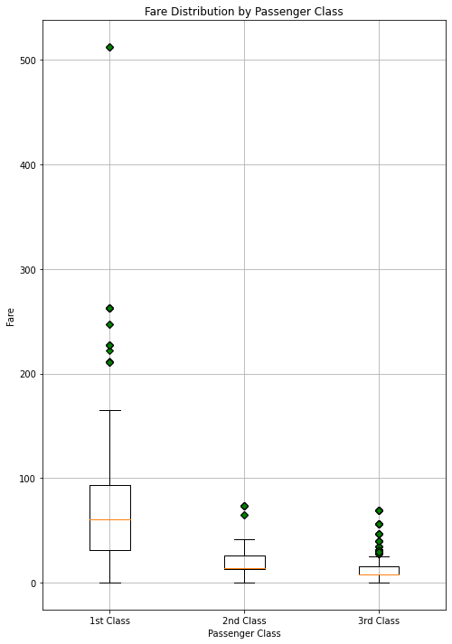

```python
# create a boxplot of fare by passenger class
plt.figure(figsize=(8,12))
green_diamond = dict(markerfacecolor='g', marker='D')
plt.boxplot([train_df[train_df['Pclass']==1]['Fare'],
             train_df[train_df['Pclass']==2]['Fare'],
             train_df[train_df['Pclass']==3]['Fare']],
            labels=['1st Class', '2nd Class', '3rd Class'] , flierprops=green_diamond)
plt.title('Fare Distribution by Passenger Class')
plt.xlabel('Passenger Class')
plt.ylabel('Fare')
plt.grid()
plt.show()
```

# (ج)

*در ابتدا تغییرات جزئی روی دیتا فریم ها اعمال می کنیم و مقادیر غیر عددی را به صورت زیر به مقادیر عددی تبدیل می کنیم*

```python
categories = {"female": 1, "male": 0}
train_df['Sex']= train_df['Sex'].map(categories)
test_df['Sex']= test_df['Sex'].map(categories)
# ------------------------------------------------------------
categories = {"S": 1, "C": 2, "Q": 3}
train_df['Embarked']= train_df['Embarked'].map(categories)
test_df['Embarked']= test_df['Embarked'].map(categories)
# ------------------------------------------------------------
categories = train_df.Cabin.unique()
train_df['Cabin'] = train_df.Cabin.astype("category").cat.codes
test_df['Cabin'] = test_df.Cabin.astype("category").cat.codes
```

*از نظر من ویژگی های مربوط به حروف بلیط و آی دی مسافران هم نمی تواند خیلی مفید باشد در نتیجه آن ها را حذف کردم*

*ستون های مربوط به بلیط اگرچه ممکن است کمی راجع به جایگاه مسافران اطلاعات بدهند اما اطلاعات آن ها کاملا توسط ستون های دیگر مثل کابین و کرایه کاور می شود*

```python
train_df = train_df.drop(['Ticket_characters','Ticket_FirstLetter','PassengerId'], axis=1)
test_df  = test_df.drop(['Ticket_characters','Ticket_FirstLetter','PassengerId'], axis=1)
```

```python
train_df.head(10)
```

|  | Survived | Pclass | Sex | Age | SibSp | Parch | Fare | Cabin | Embarked |
| --- | --- | --- | --- | --- | --- | --- | --- | --- | --- |
| 0 | 0 | 3 | 0 | 22.000000 | 1 | 0 | 7.2500 | 8 | 1 |
| 1 | 1 | 1 | 1 | 38.000000 | 1 | 0 | 71.2833 | 2 | 2 |
| 2 | 1 | 3 | 1 | 26.000000 | 0 | 0 | 7.9250 | 8 | 1 |
| 3 | 1 | 1 | 1 | 35.000000 | 1 | 0 | 53.1000 | 2 | 1 |
| 4 | 0 | 3 | 0 | 35.000000 | 0 | 0 | 8.0500 | 8 | 1 |
| 5 | 0 | 3 | 0 | 33.118395 | 0 | 0 | 8.4583 | 8 | 3 |
| 6 | 0 | 1 | 0 | 54.000000 | 0 | 0 | 51.8625 | 4 | 1 |
| 7 | 0 | 3 | 0 | 2.000000 | 3 | 1 | 21.0750 | 8 | 1 |
| 8 | 1 | 3 | 1 | 27.000000 | 0 | 2 | 11.1333 | 8 | 1 |
| 9 | 1 | 2 | 1 | 14.000000 | 1 | 0 | 30.0708 | 8 | 2 |

```python
test_df.head(10)
```

|  | Pclass | Sex | Age | SibSp | Parch | Fare | Cabin | Embarked | Survived |
| --- | --- | --- | --- | --- | --- | --- | --- | --- | --- |
| 0 | 3 | 0 | 34.5 | 0 | 0 | 7.8292 | 7 | 3 | 0.0 |
| 1 | 3 | 1 | 47.0 | 1 | 0 | 7.0000 | 7 | 1 | 1.0 |
| 2 | 2 | 0 | 62.0 | 0 | 0 | 9.6875 | 7 | 3 | 0.0 |
| 3 | 3 | 0 | 27.0 | 0 | 0 | 8.6625 | 7 | 1 | 0.0 |
| 4 | 3 | 1 | 22.0 | 1 | 1 | 12.2875 | 7 | 1 | 1.0 |
| 5 | 3 | 0 | 14.0 | 0 | 0 | 9.2250 | 7 | 1 | 1.0 |
| 6 | 3 | 1 | 30.0 | 0 | 0 | 7.6292 | 7 | 3 | 1.0 |
| 7 | 2 | 0 | 26.0 | 1 | 1 | 29.0000 | 1 | 1 | 1.0 |
| 8 | 3 | 1 | 18.0 | 0 | 0 | 7.2292 | 7 | 2 | 1.0 |
| 9 | 3 | 0 | 21.0 | 2 | 0 | 24.1500 | 7 | 1 | 0.0 |

## Data Normalization :

```python
# Dropping label

y_train = train_df['Survived']
train_df = train_df.drop('Survived', axis=1)  # Dropping label to normalize

y_test = test_df['Survived']
test_df = test_df.drop('Survived', axis=1)  # Dropping label to normalize
```

```python
scaler = MinMaxScaler()
scaled_train = scaler.fit_transform(train_df)
scaled_test = scaler.transform(test_df)

scaled_train = pd.DataFrame(scaled_train, columns=train_df.columns, index=train_df.index)
scaled_test  = pd.DataFrame(scaled_test, columns=test_df.columns, index=test_df.index)
```

```python
scaled_train.head(10)
```

|  | Pclass | Sex | Age | SibSp | Parch | Fare | Cabin | Embarked |
| --- | --- | --- | --- | --- | --- | --- | --- | --- |
| 0 | 1.0 | 0.0 | 0.271174 | 0.125 | 0.000000 | 0.014151 | 1.00 | 0.0 |
| 1 | 0.0 | 1.0 | 0.472229 | 0.125 | 0.000000 | 0.139136 | 0.25 | 0.5 |
| 2 | 1.0 | 1.0 | 0.321438 | 0.000 | 0.000000 | 0.015469 | 1.00 | 0.0 |
| 3 | 0.0 | 1.0 | 0.434531 | 0.125 | 0.000000 | 0.103644 | 0.25 | 0.0 |
| 4 | 1.0 | 0.0 | 0.434531 | 0.000 | 0.000000 | 0.015713 | 1.00 | 0.0 |
| 5 | 1.0 | 0.0 | 0.410887 | 0.000 | 0.000000 | 0.016510 | 1.00 | 1.0 |
| 6 | 0.0 | 0.0 | 0.673285 | 0.000 | 0.000000 | 0.101229 | 0.50 | 0.0 |
| 7 | 1.0 | 0.0 | 0.019854 | 0.375 | 0.166667 | 0.041136 | 1.00 | 0.0 |
| 8 | 1.0 | 1.0 | 0.334004 | 0.000 | 0.333333 | 0.021731 | 1.00 | 0.0 |
| 9 | 0.5 | 1.0 | 0.170646 | 0.125 | 0.000000 | 0.058694 | 1.00 | 0.5 |

```python
scaled_test.head(10)
```

|  | Pclass | Sex | Age | SibSp | Parch | Fare | Cabin | Embarked |
| --- | --- | --- | --- | --- | --- | --- | --- | --- |
| 0 | 1.0 | 0.0 | 0.428248 | 0.000 | 0.000000 | 0.015282 | 0.875 | 1.0 |
| 1 | 1.0 | 1.0 | 0.585323 | 0.125 | 0.000000 | 0.013663 | 0.875 | 0.0 |
| 2 | 0.5 | 0.0 | 0.773813 | 0.000 | 0.000000 | 0.018909 | 0.875 | 1.0 |
| 3 | 1.0 | 0.0 | 0.334004 | 0.000 | 0.000000 | 0.016908 | 0.875 | 0.0 |
| 4 | 1.0 | 1.0 | 0.271174 | 0.125 | 0.166667 | 0.023984 | 0.875 | 0.0 |
| 5 | 1.0 | 0.0 | 0.170646 | 0.000 | 0.000000 | 0.018006 | 0.875 | 0.0 |
| 6 | 1.0 | 1.0 | 0.371701 | 0.000 | 0.000000 | 0.014891 | 0.875 | 1.0 |
| 7 | 0.5 | 0.0 | 0.321438 | 0.125 | 0.166667 | 0.056604 | 0.125 | 0.0 |
| 8 | 1.0 | 1.0 | 0.220910 | 0.000 | 0.000000 | 0.014110 | 0.875 | 0.5 |
| 9 | 1.0 | 0.0 | 0.258608 | 0.250 | 0.000000 | 0.047138 | 0.875 | 0.0 |

```python
# making a copy of this dataframe for part D
D_test = scaled_test.copy()
```

```python
clf = RandomForestClassifier(n_estimators=100)
clf.fit(scaled_train, y_train)
```

```
RandomForestClassifier()
```

```
   Accuracy: 0.715311004784689
              precision    recall  f1-score   support

         0.0       0.80      0.75      0.77       271
         1.0       0.59      0.65      0.62       147

    accuracy                           0.72       418
   macro avg       0.69      0.70      0.70       418
weighted avg       0.72      0.72      0.72       418
```

|  | Pclass | Sex | Age | SibSp | Parch | Fare | Cabin | Embarked | Survival_Predictions |
| --- | --- | --- | --- | --- | --- | --- | --- | --- | --- |
| 0 | 1.0 | 0.0 | 0.428248 | 0.000 | 0.000000 | 0.015282 | 0.875 | 1.0 | 0 |
| 1 | 1.0 | 1.0 | 0.585323 | 0.125 | 0.000000 | 0.013663 | 0.875 | 0.0 | 0 |
| 2 | 0.5 | 0.0 | 0.773813 | 0.000 | 0.000000 | 0.018909 | 0.875 | 1.0 | 0 |
| 3 | 1.0 | 0.0 | 0.334004 | 0.000 | 0.000000 | 0.016908 | 0.875 | 0.0 | 1 |
| 4 | 1.0 | 1.0 | 0.271174 | 0.125 | 0.166667 | 0.023984 | 0.875 | 0.0 | 0 |

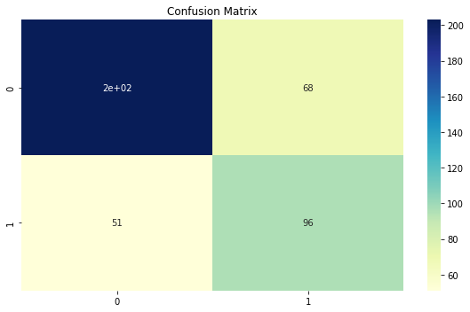

```python
y_pred = clf.predict(scaled_test)

print("   Accuracy: {}".format(metrics.accuracy_score(y_test, y_pred)))

print(classification_report(y_test,y_pred))

conf_matrix = confusion_matrix(y_test, y_pred)

plt.figure(figsize=(8,5))
sns.heatmap(conf_matrix, annot=True ,cmap="YlGnBu")
plt.title('Confusion Matrix')
plt.tight_layout()

prediction = clf.predict(scaled_test)

scaled_test['Survival_Predictions'] = pd.Series(prediction)
scaled_test.head()
```

# (د)

```python
D_train = scaled_train.copy()
# I have already made D_test In the previous part.
```

```python
D_test.head()
```

|  | Pclass | Sex | Age | SibSp | Parch | Fare | Cabin | Embarked |
| --- | --- | --- | --- | --- | --- | --- | --- | --- |
| 0 | 1.0 | 0.0 | 0.428248 | 0.000 | 0.000000 | 0.015282 | 0.875 | 1.0 |
| 1 | 1.0 | 1.0 | 0.585323 | 0.125 | 0.000000 | 0.013663 | 0.875 | 0.0 |
| 2 | 0.5 | 0.0 | 0.773813 | 0.000 | 0.000000 | 0.018909 | 0.875 | 1.0 |
| 3 | 1.0 | 0.0 | 0.334004 | 0.000 | 0.000000 | 0.016908 | 0.875 | 0.0 |
| 4 | 1.0 | 1.0 | 0.271174 | 0.125 | 0.166667 | 0.023984 | 0.875 | 0.0 |

```python
# define the hyperparameter grid to search
param_grid = {
    'criterion': ['gini', 'entropy'],
    'min_samples_leaf': [1, 3, 5],
    'min_samples_split': [2, 4, 6],
    'n_estimators': [50, 100, 150]
}

# create a Random Forest Classifier
rfc = RandomForestClassifier(random_state=42)

# use GridSearchCV to find the best hyperparameters
grid_search = GridSearchCV(rfc, param_grid=param_grid, cv=5)
grid_search.fit(D_train, y_train)

# print the best hyperparameters and their corresponding accuracy
print("Best hyperparameters: ", grid_search.best_params_)
print("Best accuracy: ", grid_search.best_score_)

# train a new model using the best hyperparameters
best_params = grid_search.best_params_
rfc = RandomForestClassifier(random_state=42, **best_params)
rfc.fit(D_train, y_train)

# evaluate the model on the test set
y_pred = rfc.predict(D_test)
test_acc = accuracy_score(y_test, y_pred)
print("Test accuracy: ", test_acc)
```

```
Best hyperparameters:  {'criterion': 'entropy', 'min_samples_leaf': 3, 'min_samples_split': 2, 'n_estimators': 50}
Best accuracy:  0.8294394576611637
Test accuracy:  0.7464114832535885
```

# (ه)

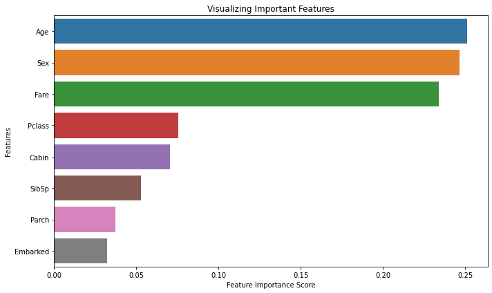

```python
feature_imp = pd.Series(clf.feature_importances_, index=scaled_train.columns).sort_values(ascending=False)
plt.figure(figsize=(10,6))
sns.barplot(x=feature_imp, y=feature_imp.index)
# Add labels to your graph
plt.xlabel('Feature Importance Score')
plt.ylabel('Features')
plt.title("Visualizing Important Features")
plt.tight_layout()
```

*مشاهده می شود که ویژگی ها به ترتیب اهمیت لیست شده اند در شکل بالا. طبق خواسته ی سوال کم اهمیت ترین آن ها را حذف می کنیم و مجدد قسمت قبل را تکرار می کنیم*

```python
D_test  = D_test.drop('Embarked', axis=1)  # Dropping label to normalize
D_train = D_train.drop('Embarked', axis=1)  # Dropping label to normalize
```

```python
# define the hyperparameter grid to search
param_grid = {
    'criterion': ['gini', 'entropy'],
    'min_samples_leaf': [1, 3, 5],
    'min_samples_split': [2, 4, 6],
    'n_estimators': [50, 100, 150]
}

# create a Random Forest Classifier
rfc = RandomForestClassifier(random_state=42)

# use GridSearchCV to find the best hyperparameters
grid_search = GridSearchCV(rfc, param_grid=param_grid, cv=5)
grid_search.fit(D_train, y_train)

# print the best hyperparameters and their corresponding accuracy
print("Best hyperparameters: ", grid_search.best_params_)
print("Best accuracy: ", grid_search.best_score_)

# train a new model using the best hyperparameters
best_params = grid_search.best_params_
rfc = RandomForestClassifier(random_state=42, **best_params)
rfc.fit(D_train, y_train)

# evaluate the model on the test set
y_pred = rfc.predict(D_test)
test_acc = accuracy_score(y_test, y_pred)
print("Test accuracy: ", test_acc)
```

```
Best hyperparameters:  {'criterion': 'gini', 'min_samples_leaf': 3, 'min_samples_split': 2, 'n_estimators': 50}
Best accuracy:  0.8327976900382901
Test accuracy:  0.7679425837320574
```